# CS230 Project final

[figure not shown]

**Students : Othman Bensouda Koraichi**

1. Introduction
   1. Problem
   2. Research questions
2. Libraries
3. Data
   1. Dataset
   2. Data dictionary
   3. Data cleaning (general)
      1. Misalignments
      2. Duplicates
      3. Unnecessary columns
      4. Clean names
      5. Data type
      6. Repetitive answers
4. Training and testing sets
5. Bayesian Knowledge Tracing
   1. Library for BKT
   2. Data cleaning (specific to BKT)
      1. Change column names to fit with the library
   3. BKT Model
   4. Results
6. Deep Knowledge Tracing
   1. Data cleaning (specific to neural networks)
      1. Standardize categorical variables
      2. Standardize numeric variables
      3. Create sequences of data for each user
   2. Training, validation, and testing sets
   3. Model
      1. Helper functions
         1. Get Data function
         2. Get Sequence function
         3. Pad function
         4. Apply to all function
         5. Run model function
   4. Run all models
      1. Simple model
      2. Model with time to answer
      3. Model with domains
      4. Model with skills
      5. Model with subskills
      6. Model with questions
      7. Model with number of attempts
      8. Metamodel
7. Analysis of results
8. References

# Introduction

## Problem

Student knowledge measurement is central in learning environments to provide feedback, evaluate educational programs, set goals and make learning-oriented decisions. This task is inherently difficult as human learning is grounded in the complexity of both the human brain and human knowledge. Thus, the use of complex models seems appropriate. Nevertheless, previous work mainly relies on Hidden Markov models containing several statistical problems. Knowledge tracing is the task of modeling student knowledge over time so that it can be predicted how students will perform on future interactions. Each time the student answers an exercise, a prediction is made as to whether or not they would answer an exercise of each type correctly on their next interaction. Deep Knowledge Tracing (DKT) is a subset of Knowledge Tracing in which flexible recurrent neural networks (RNN) are applied for the task of modeling student knowledge. This method, first published by Chris Piech in 2015, has proved to outperform traditional knowledge tracing methods. However, RNNs were trained on datasets which only contained binary data about the correctness of answers (e.g whether a user correctly answered (1) or incorrectly answered (0) a question). The latest available literature suggested incorporating several new features to further ameliorate the accuracy of the DKT algorithm. Hence, the core of the project is to write a Deep Learning algorithm that predicts whether a student is going to answer a question correctly within a quiz. This task is important because it allows intelligent tutoring systems to calibrate the difficulty of the questions that they will show to students. If a student is shown too many questions that they can’t answer, the student will become frustrated, and will stop learning. If a student is shown too many questions that they can answer easily, the student will become uninterested, and will stop learning. While I find replicating Chris Piech’s work with our own data interesting, I also want to investigate whether adding other inputs, such as time to answer, skill, sub-skill etc. would further improve the accuracy of the DKT algorithm.

## Research questions

**In this project, we will** :

● Explore whether Deep Knowledge Tracing generalizes well. In other words, we will test whether DKT still performs better than BKT on a different dataset than the ones initially used in Chris Piech’s project.

● Explore whether new inputs, such as time to answer, skill, sub-skill etc. can improve the performance of DKT, as suggested by Chris Piech.

These answers are important because they can inform the companies that develop intelligent tutoring systems, about which algorithm they should use to better predict performance (BKT or DKT), and which data they need to collect in order to feed these algorithms.

# Libraries

```python
# Import libraries
from IPython.display import display
import pandas as pd
from sklearn.preprocessing import OneHotEncoder
from sklearn.preprocessing import MinMaxScaler
import os
import janitor
import numpy as np
import matplotlib.pyplot as plt
from sklearn.model_selection import GroupShuffleSplit
from keras.models import Sequential
from keras.layers import Dense
from keras.layers import LSTM
import sklearn
from pyBKT.models import Model
import tensorflow as tf
from matplotlib import pyplot
```

# Data

## Dataset

We test our ability to predict student performance on a dataset obtained specifically for this research, coming from Workera, a platform that offers adaptive assessments on specific areas of knowledge useful for Data Science related positions. The uniqueness of this dataset not only allows us to reproduce and test previous work, but also to incorporate new inputs which have not been analyzed by other researchers to the best of the author's knowledge.

```python
# We read the data
data = pd.read_csv('gs://bucket_unilever/LSTM O/report-from-2021-08.csv',error_bad_lines=False)
```

```python
# We observe the first 5 rows
data.head(5)
```

|  | User ID | Domain | Skill | Sub-skill | Question | Date | Time to answer | Attempt | Correct 1-Incorrect 0-Dont know NULL | Learning Time | Score | Target Score |
| --- | --- | --- | --- | --- | --- | --- | --- | --- | --- | --- | --- | --- |
| 0 | 3111 | Data Visualization | Visualization Charts and Methods | Interpret marimekko and mosaic charts | 2,509.00000 | 2022-01-26 19:46:52.918262+00 | 186.00000 | 1.00000 | 0.00000 | 1.00000 | 144.00000 | 0.00000 |
| 1 | 3111 | Data Visualization | Visualization Charts and Methods | Interpret marimekko and mosaic charts | 2,509.00000 | 2022-01-26 19:46:52.918262+00 | 186.00000 | 1.00000 | 0.00000 | 1.00000 | 144.00000 | 0.00000 |
| 2 | 3111 | Data Visualization | Visualization Charts and Methods | Interpret marimekko and mosaic charts | 2,509.00000 | 2022-01-26 19:46:52.918262+00 | 186.00000 | 1.00000 | 0.00000 | 1.00000 | 144.00000 | 0.00000 |
| 3 | 3111 | Data Visualization | Visualization Charts and Methods | Interpret marimekko and mosaic charts | 2,509.00000 | 2022-01-26 19:46:52.918262+00 | 186.00000 | 1.00000 | 0.00000 | 1.00000 | 144.00000 | 0.00000 |
| 4 | 3111 | Data Visualization | Visualization Charts and Methods | Interpret marimekko and mosaic charts | 2,509.00000 | 2022-01-26 19:46:52.918262+00 | 186.00000 | 1.00000 | 0.00000 | 1.00000 | 144.00000 | 0.00000 |

```python
# We observe the shape of the data. 7.5M rows and 12 variables.
data.shape
```

```
(7508490, 12)
```

## Data dictionary

The following dataframe summarizes the different variables and their description.

```python
# Display data dictionary
data_dic = pd.read_excel('gs://bucket_unilever/LSTM O/data dic.xlsx')
pd.set_option('max_colwidth', 400)
data_dic
```

|  | Variable name | Description | Example |
| --- | --- | --- | --- |
| 0 | USER ID | Numeric variable uniquely identifying a user | 136896 |
| 1 | DOMAIN | Character variable representing the domain of expertise | Software Engineering |
| 2 | SKILL | Character variable describing the skill corresponding to a question | Coding methods |
| 3 | SUB-SKILL | Character variable describing the sub-skill within a certain skill | Implementing a code solution to solve a problem |
| 4 | QUESTION ID | Numeric variable uniquely identifying a question | 908 |
| 5 | DATE | Date variable representing the time at which a question has been answered | 2021-08-01 19:46:52 |
| 6 | TIME TO ANSWER | Numeric variable representing the time that the user took to answer a question (in seconds) | 186 |
| 7 | ATTEMPT | Numeric variable describing the number of attempts of a user for a certain question | 4 |
| 8 | CORRECT/INCORRECT/DO NOT KNOW | Categorical variable describing the outcome : 1 if correct, 0 if incorrect, null if the user does not know the answer | 0 |
| 9 | LEARNING TIME | Numeric variable representing the learning time estimated by the company, in hours | 1 |
| 10 | SCORE | Numeric variable representing the score reached by the user for a certain domain | 188 |
| 11 | TARGET SCORE | Numeric variable representing the target score aimed by the user | 191 |

## Data Cleaning (general)

### Misalignments

There are misalignments of columns in the raw dataset so we have to delete all the rows having information that do not match with the column name (approximately 20K rows out of 1.2M rows). In this picture, we notice that the 'Date' column does not contain dates but rather skills, and the 'Attempt' column contains dates instead.

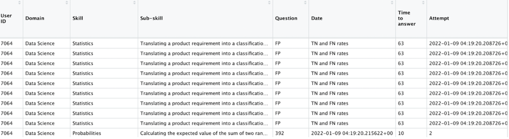

```python
def clean_misalignments(dataset_name):
    with open(f"{dataset_name}.csv", "r") as f:
        txt = f.read()
    txt = txt.replace("idempotency\n", "idempotency")

    # problem in the data is that "sub-skill"
    # has names with "," in it
    txt_ls = txt.split("\n")
    txt_set = set([t.rsplit(",", 8)[0] for t in txt_ls])
    txt_set = set([t.split(",", 3)[-1] for t in txt_set])
    problematic = [t for t in txt_set if t.count(",")>0]

    print("solving problems for problematic cases: ")
    display(problematic)
    for passage in problematic:
        txt = txt.replace(passage, passage.replace(",", "$"))

    with open(f"{dataset_name}_cleaned.csv", "w") as f:
        f.write(txt)
```

```python
# We apply the function
clean_misalignments('/Users/mydodethailung/Desktop/EDS seminar/EDS project/report-from-2021-08')
```

```python
# We read the cleaned dataset
data = pd.read_csv('gs://bucket_unilever/LSTM O/report-from-2021-08_cleaned.csv')
```

### Duplicates

Looking at the raw data, we observee many duplicate rows. From the initial 7.5 million rows, we end up with 1.2 million rows, after removing all perfect duplicates

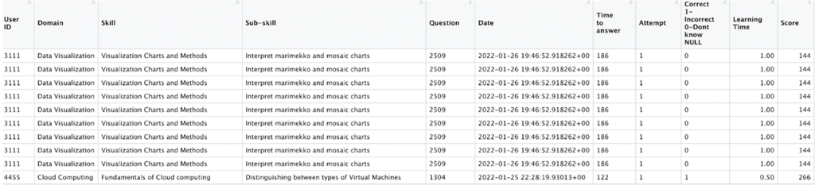

```python
# We drop duplicates
data = data.drop_duplicates(ignore_index= True)
# We observe the new shape
data.shape
```

```
(1267132, 12)
```

### Unnecessary columns

Some columns are unnecessary for the scope of this project. Thus, we will drop them.

```python
# Remove unnecessary columns and duplicates
df_general = data.drop(['Learning Time','Score','Target Score'], axis = 1).reset_index(drop = True)
```

### Binarize the outcome

Currently, the variable defining correctness of answers has 3 outcomes : 1 for a correct answer, 0 for an incorrect answer, and a null value if the user did not answer. For this project, we will binarize this variable and consider that no answer is equivalent to having a wrong answer because the student does not know the correct answer.

```python
# For the "correct" column, consider that no answer is an incorrect answer
df_general['Correct 1-Incorrect 0-Dont know NULL'] = df_general['Correct 1-Incorrect 0-Dont know NULL'].fillna(0)
```

### Remove NA values

We remove the NA values from the dataset.

```python
df_general = df_general.dropna()
```

### Clean names

The names of our variables contain capital letters,spaces, and other symbols. We use the janitor function to simplify these names.

```python
df_general = df_general.clean_names()
df_general.head(5)
# Rename the column representing correctness of answer
df_general.rename(columns = {'correct_1_incorrect_0_dont_know_null':'correct'}, inplace = True)
```

### Data type

Some data types are not appropriate. We convert them to the right data types.

```python
# Observe the data types
df_general.info()
```

```
<class 'pandas.core.frame.DataFrame'>
Int64Index: 1254215 entries, 0 to 1267131
Data columns (total 9 columns):
 #   Column          Non-Null Count    Dtype
---  ------          --------------    -----
 0   user_id         1254215 non-null  float64
 1   domain          1254215 non-null  object
 2   skill           1254215 non-null  object
 3   sub_skill       1254215 non-null  object
 4   question        1254215 non-null  int64
 5   date            1254215 non-null  object
 6   time_to_answer  1254215 non-null  int64
 7   attempt         1254215 non-null  int64
 8   correct         1254215 non-null  float64
dtypes: float64(2), int64(3), object(4)
memory usage: 95.7+ MB
```

```python
# Change the user ID and the correctness column to integers
# Change date column to date
df_general["correct"] = df_general["correct"].astype(int)
df_general["date"] = pd.to_datetime(df_general["date"])
df_general["user_id"] = df_general["user_id"].astype(int)
```

```python
df_general.head()
```

|  | user_id | domain | skill | sub_skill | question | date | time_to_answer | attempt | correct |
| --- | --- | --- | --- | --- | --- | --- | --- | --- | --- |
| 0 | 3111 | Data Visualization | Visualization Charts and Methods | Interpret marimekko and mosaic charts | 2509 | 2022-01-26 19:46:52.918262+00:00 | 186 | 1 | 0 |
| 1 | 4455 | Cloud Computing | Fundamentals of Cloud computing | Distinguishing between types of Virtual Machines | 1304 | 2022-01-25 22:28:19.930130+00:00 | 122 | 1 | 1 |
| 2 | 5541 | Machine Learning | Understanding methods to train ML models | Differentiating stochastic from batch gradient descent in machine learning | 40 | 2022-01-16 18:54:05.659029+00:00 | 30 | 4 | 0 |
| 3 | 5541 | Machine Learning | Understanding methods to train ML models | Differentiating stochastic from batch gradient descent in machine learning | 40 | 2022-01-16 18:54:44.283979+00:00 | 30 | 4 | 0 |
| 4 | 5541 | Machine Learning | Understanding methods to train ML models | Differentiating stochastic from batch gradient descent in machine learning | 40 | 2022-01-16 18:55:54.462949+00:00 | 30 | 4 | 0 |

### Repetitive answers

You might have noticed that some rows correspond to the same user and the same question, but have a difference of a few miliseconds. We will solve this problem by taking the first instance of each set of user & question.

```python
df_general = df_general.groupby(['user_id','question']).first().reset_index()
```

# Training and testing sets

Let us randomly choose the users that will be in the training, testing and validation sets of the BKT and the DKT models. Remember that each user has a sequence of questions, so we should not split the dataset by rows, but rather by users ! In other words, we should not choose 80% of rows as the training set, but 80% of users.

```python
# We use scikit learn to split our dataset by groups (here, we want to choose 80% of users for the training set)
# For BKT, we will only have a training set and a testing set (80% 20%).
# For DKT, the testing set will be split in 2 because we will also have a validation set.(80% 10% 10%)
splitter = sklearn.model_selection.GroupShuffleSplit(test_size=.20, random_state = 7)
split = splitter.split(df_general, groups=df_general['user_id'])
train_inds, test_inds = next(split)

train = df_general.iloc[train_inds]
test = df_general.iloc[test_inds]
```

```python
len(set(train['user_id']))
```

```
7811
```

```python
# We check that our split makes sense
print("Number of training users : %f" %len(set(train['user_id'])))
print("Number of testing users : %f" %len(set(test['user_id'])))
```

```
Number of training users : 7811.000000
Number of testing users : 1953.000000
```

# Bayesian Knowledge Tracing

In recent years, Corbett & Anderson’s Bayesian Knowledge Tracing model (BKT) has been used to model student knowledge in a variety of systems. BKT models a learner’s latent knowledge state as a set of binary variables, each of which represents understanding or non-understanding of a certain domain. A Hidden Markov Model (HMM) is used to update the probabilities across each of these binary variables, as a learner answers exercises of a given domain correctly or incorrectly.

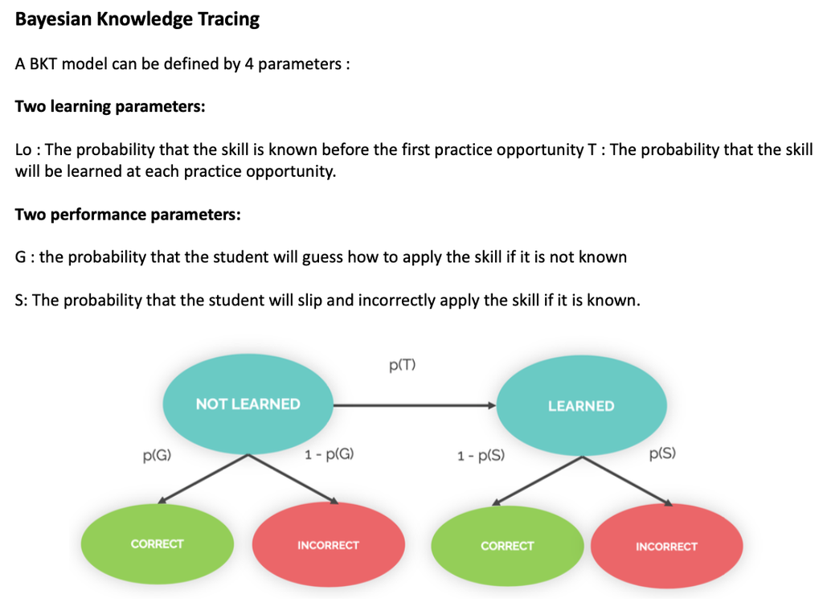

## Library for BKT

We will use the pyBKT library, based on the work of Zachary A. Pardos (zp@berkeley.edu) and Matthew J. Johnson (mattjj@csail.mit.edu) @ https://github.com/CAHLR/xBKT

pyBKT models student mastery of a skills as they progress through series of learning resources and checks for understanding. Mastery is modelled as a latent variable has two states - "knowing" and "not knowing". At each checkpoint, students may be given a learning resource (i.e. watch a video) and/or question(s) to check for understanding. The model finds the probability of learning, forgetting, slipping and guessing that maximizes the likelihood of observed student responses to questions.

## Data cleaning (specific to BKT)

### Change column names to fit with the library

The pyBKT library requires that we change some of our column names.

```python
# Rename the domain column, that we will consider as the skills in our models.
df_bkt = df_general.copy(deep=True)
df_bkt.rename(columns = {'domain':'skill_name'}, inplace = True)
```

```python
df_bkt_train = df_bkt.iloc[train_inds]
df_bkt_test = df_bkt.iloc[test_inds]
```

We check the shape of our dataframes to make sure that the split is correct

```python
df_bkt.shape
```

```
(465441, 9)
```

```python
df_bkt_train.shape
```

```
(370423, 9)
```

```python
df_bkt_test.shape
```

```
(95018, 9)
```

## BKT Model

We initialize the model.

```python
# Initialize model
model = Model(seed = 42, num_fits = 1)
```

We fit the model on our training set.

```python
# Fit the model for the training and the testing set
model.fit(data = df_bkt_train)
```

We predict the outcomes.

```python
# Predict outcomes
preds_train = model.predict(data = df_bkt_train)
preds_test = model.predict(data = df_bkt_test)
```

```python
preds_train.head()
```

|  | Unnamed: 0 | user_id | question | skill_name | skill | sub_skill | date | time_to_answer | attempt | correct | correct_predictions | state_predictions |
| --- | --- | --- | --- | --- | --- | --- | --- | --- | --- | --- | --- | --- |
| 0 | 17 | 1365 | 1858 | Introduction to Data Analytics | Fundamentals of data analytics | Define sample vs population | 2021-10-26 20:45:02.390491+00:00 | 30 | 1 | 0 | 0.31658 | 0.01639 |
| 1 | 18 | 1365 | 1860 | Introduction to Data Analytics | Fundamentals of data analytics | Differentiate independent vs dependent variables | 2021-10-26 20:45:02.400570+00:00 | 33 | 1 | 1 | 0.38059 | 0.17737 |
| 2 | 19 | 1365 | 1861 | Introduction to Data Analytics | Fundamentals of data analytics | Define diagnostic analytics | 2021-10-26 20:45:02.387396+00:00 | 25 | 1 | 1 | 0.48693 | 0.44480 |
| 3 | 20 | 1365 | 1862 | Introduction to Data Analytics | Data analysis phases | Understand mean vs. median vs. mode | 2021-10-26 20:45:02.393067+00:00 | 72 | 1 | 1 | 0.59125 | 0.70712 |
| 4 | 21 | 1365 | 1863 | Introduction to Data Analytics | Data analysis phases | Recognize inferential analytics use cases | 2021-10-26 20:45:02.403379+00:00 | 29 | 1 | 0 | 0.65712 | 0.87276 |

```python
preds_test.head()
```

|  | Unnamed: 0 | user_id | question | skill_name | skill | sub_skill | date | time_to_answer | attempt | correct | correct_predictions | state_predictions |
| --- | --- | --- | --- | --- | --- | --- | --- | --- | --- | --- | --- | --- |
| 0 | 0 | 1020 | 13 | Data Science | Statistics | Calculate the variance of a random variable | 2021-12-01 20:54:14.645347+00:00 | 21 | 4 | 1 | 0.44871 | 0.82380 |
| 1 | 1 | 1020 | 17 | Data Science | Statistics | Analyzing a residuals plot | 2021-12-01 20:54:14.636643+00:00 | 203 | 4 | 0 | 0.48487 | 0.93196 |
| 2 | 2 | 1020 | 54 | Data Science | Structuring machine learning projects | Choosing the correct evaluation metrics for imbalanced datasets | 2021-12-01 20:54:14.651360+00:00 | 22 | 4 | 0 | 0.47112 | 0.89082 |
| 3 | 3 | 1020 | 135 | Data Science | Probabilities | Recognizing the mean and variance of a normal distribution on a frequency plot | 2021-12-01 20:54:14.648349+00:00 | 28 | 4 | 0 | 0.45058 | 0.82938 |
| 4 | 4 | 1020 | 142 | Data Science | Statistics | Understanding the properties of a latent variable | 2021-12-01 20:54:14.642095+00:00 | 12 | 4 | 0 | 0.42181 | 0.74333 |

## Results

We define our metrics to analyze our results. We will use the RMSE and the AUC for the training and testing sets.

```python
rmse_train = model.evaluate(data = df_bkt_train )
auc_train = model.evaluate(data = df_bkt_train, metric = 'auc')
print("RMSE training: %f" % rmse_train)
print("AUC training: %f" % auc_train)
rmse_test = model.evaluate(data = df_bkt_test )
auc_test = model.evaluate(data = df_bkt_test, metric = 'auc')
print("RMSE testing: %f" % rmse_test)
print("AUC testing: %f" % auc_test)
```

```
RMSE training: 0.482926
AUC training: 0.638069
RMSE testing: 0.484639
AUC testing: 0.630785
```

The performance on the training set and on the testing set is almost similar, showing that the model generalizes well and that we did not overfit.

# Deep Knowledge Tracing

## Data cleaning (specific to neural networks)

First of all, we will create functions to standardize categorical variables.

### Standardize categorical variables

We need to one hot encode our categorical variables.

```python
def one_hot(df):
    categorical_cols = ['skill','sub_skill','domain','question']
    df = pd.get_dummies(df, columns = categorical_cols)
    return df
```

### Standardize numeric variables

We need to scale our numeric variable, otherwise the weights in our neural network might be biased. We will do so with a minmax scaler :

\begin{equation} X_{s c}=\frac{X-X_{\min }}{X_{\max }-X_{\min }} \end{equation}

```python
def minmax(df):
    # Create scaler
    scaler = MinMaxScaler(feature_range=(0,1))
    # Fit the minmax scaler
    df[['time_to_answer_t_1','attempt']] = scaler.fit_transform(df[['time_to_answer_t_1','attempt']])
    return df
```

### Create sequences of data for each user

We want to create sequences of data for each user. This means that for each user, we want the sequence of questions that they answered for each domain, in the right order.

```python
df_neural_net = df_general.copy(deep=True)
df_neural_net = df_neural_net.groupby(["user_id"]).apply(lambda x: x.sort_values(["date"], ascending = True)).reset_index(drop=True)

# Create a t+1 column
df_neural_net['correct t-1'] = df_neural_net.groupby(['user_id'])['correct'].shift(1)
df_neural_net['time_to_answer_t_1'] = df_neural_net.groupby(['user_id'])['time_to_answer'].shift(1)
df_neural_net = df_neural_net[df_neural_net['correct t-1'].notna()]
df_neural_net = one_hot(df_neural_net)
df_neural_net = minmax(df_neural_net)


df_neural_net.head(20)
```

|  | user_id | date | time_to_answer | attempt | correct | correct t-1 | time_to_answer_t_1 | skill_AI Capabilities | skill_AI Concepts | skill_AWS architecture | ... | question_2893 | question_2894 | question_2895 | question_2896 | question_2897 | question_2898 | question_2899 | question_2900 | question_2997 | question_3004 |
| --- | --- | --- | --- | --- | --- | --- | --- | --- | --- | --- | --- | --- | --- | --- | --- | --- | --- | --- | --- | --- | --- |
| 1 | 1020 | 2021-11-02 16:05:40.330501+00:00 | 120 | 0.01613 | 0 | 0.00000 | 0.12500 | 0 | 0 | 0 | ... | 0 | 0 | 0 | 0 | 0 | 0 | 0 | 0 | 0 | 0 |
| 2 | 1020 | 2021-11-02 16:05:40.333789+00:00 | 120 | 0.01613 | 0 | 0.00000 | 0.10000 | 0 | 0 | 0 | ... | 0 | 0 | 0 | 0 | 0 | 0 | 0 | 0 | 0 | 0 |
| 3 | 1020 | 2021-11-02 16:05:40.336852+00:00 | 120 | 0.01613 | 0 | 0.00000 | 0.10000 | 0 | 0 | 0 | ... | 0 | 0 | 0 | 0 | 0 | 0 | 0 | 0 | 0 | 0 |
| 4 | 1020 | 2021-11-02 16:05:40.339590+00:00 | 10 | 0.01613 | 0 | 0.00000 | 0.10000 | 0 | 0 | 0 | ... | 0 | 0 | 0 | 0 | 0 | 0 | 0 | 0 | 0 | 0 |
| 5 | 1020 | 2021-11-02 16:05:40.342447+00:00 | 5 | 0.01613 | 0 | 0.00000 | 0.00833 | 0 | 0 | 0 | ... | 0 | 0 | 0 | 0 | 0 | 0 | 0 | 0 | 0 | 0 |
| 6 | 1020 | 2021-11-02 16:05:40.345689+00:00 | 10 | 0.01613 | 0 | 0.00000 | 0.00417 | 0 | 0 | 0 | ... | 0 | 0 | 0 | 0 | 0 | 0 | 0 | 0 | 0 | 0 |
| 7 | 1020 | 2021-11-02 16:05:40.348319+00:00 | 12 | 0.01613 | 1 | 0.00000 | 0.00833 | 0 | 0 | 0 | ... | 0 | 0 | 0 | 0 | 0 | 0 | 0 | 0 | 0 | 0 |
| 8 | 1020 | 2021-12-01 20:54:14.636643+00:00 | 203 | 0.04839 | 0 | 1.00000 | 0.01000 | 0 | 0 | 0 | ... | 0 | 0 | 0 | 0 | 0 | 0 | 0 | 0 | 0 | 0 |
| 9 | 1020 | 2021-12-01 20:54:14.642095+00:00 | 12 | 0.04839 | 0 | 0.00000 | 0.16917 | 0 | 0 | 0 | ... | 0 | 0 | 0 | 0 | 0 | 0 | 0 | 0 | 0 | 0 |
| 10 | 1020 | 2021-12-01 20:54:14.645347+00:00 | 21 | 0.04839 | 1 | 0.00000 | 0.01000 | 0 | 0 | 0 | ... | 0 | 0 | 0 | 0 | 0 | 0 | 0 | 0 | 0 | 0 |
| 11 | 1020 | 2021-12-01 20:54:14.648349+00:00 | 28 | 0.04839 | 0 | 1.00000 | 0.01750 | 0 | 0 | 0 | ... | 0 | 0 | 0 | 0 | 0 | 0 | 0 | 0 | 0 | 0 |
| 12 | 1020 | 2021-12-01 20:54:14.651360+00:00 | 22 | 0.04839 | 0 | 0.00000 | 0.02333 | 0 | 0 | 0 | ... | 0 | 0 | 0 | 0 | 0 | 0 | 0 | 0 | 0 | 0 |
| 13 | 1020 | 2021-12-01 20:54:14.654430+00:00 | 28 | 0.04839 | 1 | 0.00000 | 0.01833 | 0 | 0 | 0 | ... | 0 | 0 | 0 | 0 | 0 | 0 | 0 | 0 | 0 | 0 |
| 14 | 1020 | 2021-12-01 20:54:14.657157+00:00 | 11 | 0.04839 | 0 | 1.00000 | 0.02333 | 0 | 0 | 0 | ... | 0 | 0 | 0 | 0 | 0 | 0 | 0 | 0 | 0 | 0 |
| 15 | 1020 | 2021-12-01 20:54:14.660176+00:00 | 10 | 0.04839 | 1 | 0.00000 | 0.00917 | 0 | 0 | 0 | ... | 0 | 0 | 0 | 0 | 0 | 0 | 0 | 0 | 0 | 0 |
| 16 | 1020 | 2021-12-01 20:54:14.662894+00:00 | 18 | 0.04839 | 0 | 1.00000 | 0.00833 | 0 | 0 | 0 | ... | 0 | 0 | 0 | 0 | 0 | 0 | 0 | 0 | 0 | 0 |
| 18 | 1365 | 2021-10-26 20:45:02.387396+00:00 | 25 | 0.00000 | 1 | 1.00000 | 0.02083 | 0 | 0 | 0 | ... | 0 | 0 | 0 | 0 | 0 | 0 | 0 | 0 | 0 | 0 |
| 19 | 1365 | 2021-10-26 20:45:02.390491+00:00 | 30 | 0.00000 | 0 | 1.00000 | 0.02083 | 0 | 0 | 0 | ... | 0 | 0 | 0 | 0 | 0 | 0 | 0 | 0 | 0 | 0 |
| 20 | 1365 | 2021-10-26 20:45:02.393067+00:00 | 72 | 0.00000 | 1 | 0.00000 | 0.02500 | 0 | 0 | 0 | ... | 0 | 0 | 0 | 0 | 0 | 0 | 0 | 0 | 0 | 0 |
| 21 | 1365 | 2021-10-26 20:45:02.395583+00:00 | 41 | 0.00000 | 1 | 1.00000 | 0.06000 | 0 | 0 | 0 | ... | 0 | 0 | 0 | 0 | 0 | 0 | 0 | 0 | 0 | 0 |

20 rows × 2583 columns

## Training, validation, and testing sets

We create the training, validation and testing set, with similar indices as the ones used for the BKT model because we want to work on data with similar distributions.

```python
# Training set
users_training = set(df_general.iloc[train_inds]['user_id'])
df_neural_net_training = df_neural_net.loc[df_neural_net['user_id'].isin(users_training)]
#df_neural_net_training = df_neural_net_training [df_neural_net_training['domain'] == 'Machine Learning'].reset_index()
df_neural_net_training.head()
```

|  | user_id | date | time_to_answer | attempt | correct | correct t-1 | time_to_answer_t_1 | skill_AI Capabilities | skill_AI Concepts | skill_AWS architecture | ... | question_2893 | question_2894 | question_2895 | question_2896 | question_2897 | question_2898 | question_2899 | question_2900 | question_2997 | question_3004 |
| --- | --- | --- | --- | --- | --- | --- | --- | --- | --- | --- | --- | --- | --- | --- | --- | --- | --- | --- | --- | --- | --- |
| 18 | 1365 | 2021-10-26 20:45:02.387396+00:00 | 25 | 0.00000 | 1 | 1.00000 | 0.02083 | 0 | 0 | 0 | ... | 0 | 0 | 0 | 0 | 0 | 0 | 0 | 0 | 0 | 0 |
| 19 | 1365 | 2021-10-26 20:45:02.390491+00:00 | 30 | 0.00000 | 0 | 1.00000 | 0.02083 | 0 | 0 | 0 | ... | 0 | 0 | 0 | 0 | 0 | 0 | 0 | 0 | 0 | 0 |
| 20 | 1365 | 2021-10-26 20:45:02.393067+00:00 | 72 | 0.00000 | 1 | 0.00000 | 0.02500 | 0 | 0 | 0 | ... | 0 | 0 | 0 | 0 | 0 | 0 | 0 | 0 | 0 | 0 |
| 21 | 1365 | 2021-10-26 20:45:02.395583+00:00 | 41 | 0.00000 | 1 | 1.00000 | 0.06000 | 0 | 0 | 0 | ... | 0 | 0 | 0 | 0 | 0 | 0 | 0 | 0 | 0 | 0 |
| 22 | 1365 | 2021-10-26 20:45:02.398126+00:00 | 30 | 0.00000 | 0 | 1.00000 | 0.03417 | 0 | 0 | 0 | ... | 0 | 0 | 0 | 0 | 0 | 0 | 0 | 0 | 0 | 0 |

5 rows × 2583 columns

```python
# Validation and testing sets
initial_test_data = df_general.iloc[test_inds]
splitter = sklearn.model_selection.GroupShuffleSplit(test_size=0.5, random_state = 7)
split = splitter.split(initial_test_data, groups = initial_test_data['user_id'])
val_inds, new_test_inds = next(split)

# Validation
users_val = set(df_general.iloc[val_inds]['user_id'])
df_neural_net_val = df_neural_net.loc[df_neural_net['user_id'].isin(users_val)]
validation = initial_test_data.iloc[val_inds]
#df_neural_net_val = df_neural_net_val[df_neural_net_val['domain'] == 'Machine Learning'].reset_index()


# Testing
users_test = set(df_general.iloc[new_test_inds]['user_id'])
df_neural_net_test = df_neural_net.loc[df_neural_net['user_id'].isin(users_test)]
testing = initial_test_data.iloc[new_test_inds]
#df_neural_net_test = df_neural_net_test[df_neural_net_test['domain'] == 'Machine Learning'].reset_index()
```

We quickly check that the shapes of our dataframes make sense.

```python
df_neural_net_training.shape
```

```
(362612, 2583)
```

```python
df_neural_net_val.shape
```

```
(70988, 2583)
```

```python
df_neural_net_test.shape
```

```
(70572, 2583)
```

## Model

### Helper functions

Our model will need several helper functions to run. We will define and explain each of them.

#### Get data function

This function will return the data for a certain user in a specified dataframe.

```python
# Get data for a certain user
def get_data(df,user):
    return df[df["user_id"] == user].reset_index(drop = True)
```

```python
# We test the function get_data with user 1365
get_data(df_neural_net_training,1365)
```

|  | user_id | date | time_to_answer | attempt | correct | correct t-1 | time_to_answer_t_1 | skill_AI Capabilities | skill_AI Concepts | skill_AWS architecture | ... | question_2893 | question_2894 | question_2895 | question_2896 | question_2897 | question_2898 | question_2899 | question_2900 | question_2997 | question_3004 |
| --- | --- | --- | --- | --- | --- | --- | --- | --- | --- | --- | --- | --- | --- | --- | --- | --- | --- | --- | --- | --- | --- |
| 0 | 1365 | 2021-10-26 20:45:02.387396+00:00 | 25 | 0.00000 | 1 | 1.00000 | 0.02083 | 0 | 0 | 0 | ... | 0 | 0 | 0 | 0 | 0 | 0 | 0 | 0 | 0 | 0 |
| 1 | 1365 | 2021-10-26 20:45:02.390491+00:00 | 30 | 0.00000 | 0 | 1.00000 | 0.02083 | 0 | 0 | 0 | ... | 0 | 0 | 0 | 0 | 0 | 0 | 0 | 0 | 0 | 0 |
| 2 | 1365 | 2021-10-26 20:45:02.393067+00:00 | 72 | 0.00000 | 1 | 0.00000 | 0.02500 | 0 | 0 | 0 | ... | 0 | 0 | 0 | 0 | 0 | 0 | 0 | 0 | 0 | 0 |
| 3 | 1365 | 2021-10-26 20:45:02.395583+00:00 | 41 | 0.00000 | 1 | 1.00000 | 0.06000 | 0 | 0 | 0 | ... | 0 | 0 | 0 | 0 | 0 | 0 | 0 | 0 | 0 | 0 |
| 4 | 1365 | 2021-10-26 20:45:02.398126+00:00 | 30 | 0.00000 | 0 | 1.00000 | 0.03417 | 0 | 0 | 0 | ... | 0 | 0 | 0 | 0 | 0 | 0 | 0 | 0 | 0 | 0 |
| 5 | 1365 | 2021-10-26 20:45:02.400570+00:00 | 33 | 0.00000 | 1 | 0.00000 | 0.02500 | 0 | 0 | 0 | ... | 0 | 0 | 0 | 0 | 0 | 0 | 0 | 0 | 0 | 0 |
| 6 | 1365 | 2021-10-26 20:45:02.403379+00:00 | 29 | 0.00000 | 0 | 1.00000 | 0.02750 | 0 | 0 | 0 | ... | 0 | 0 | 0 | 0 | 0 | 0 | 0 | 0 | 0 | 0 |
| 7 | 1365 | 2021-10-26 20:45:02.406173+00:00 | 18 | 0.00000 | 1 | 0.00000 | 0.02417 | 0 | 0 | 0 | ... | 0 | 0 | 0 | 0 | 0 | 0 | 0 | 0 | 0 | 0 |

8 rows × 2583 columns

#### Get Sequence function

This function will return a numpy array containing values of variables specified in a list, for a certain dataframe (training, testing or validation) and for a certain user.

```python
# Get sequence for a user
def get_seq(df,user,lst):
    # Sequence of questions for a certain user
    df_user = get_data(df,user)
    # Include columns in the specified list
    df_user = df_user.loc[:, df_user.columns.isin(lst)]
    sequence = df_user.values.tolist()
    sequence = np.stack(sequence)

    return sequence
```

#### Padding function

Users in our dataset have answered a different number of questions on the platform. Thus, we define a function to pad our sequences.

```python
# Longest sequence in our dataset
# This is useful for the next padding function
max_quiz = max(df_neural_net.groupby('user_id').count().iloc[:,0])

def pad(seq_user):
    padded_sequence = np.pad(seq_user, ((0,max_quiz-seq_user.shape[0] +1),(0,0)),constant_values=(-50))
    return padded_sequence
```

#### Apply to all function

This function gets the sequence for each user, pads it, and return a stacked numpy array of the information for all users.

```python
# Apply to all users
def apply_to_all(df,lst):
    users= set(df['user_id'])
    all_data = []
    for user in users:
        seq_user = get_seq(df,user,lst)
        seq_user = pad(seq_user)
        all_data.append(seq_user)
    all_data = np.stack(all_data)
    return all_data
```

#### Run model function

This is the final function that encompasses all the helper functions that we previously created. First, we add a masking layer that ignores values equal to -50, which are the padded values. Then, we add a simple LSTM layer with 30 units. Note that various values have been tested, but the value 30 allows to have a simple model that generalizes well while still having a decent computation time.

```python
def run_model(x,y):
    train_x = apply_to_all(df_neural_net_training,x)
    train_y = apply_to_all(df_neural_net_training,y)

    val_x = apply_to_all(df_neural_net_val,x)
    val_y = apply_to_all(df_neural_net_val,y)

    test_x = apply_to_all(df_neural_net_test,x)
    test_y = apply_to_all(df_neural_net_test,y)

    model = tf.keras.models.Sequential()

    model.add(tf.keras.layers.Masking(mask_value= -50.,
                                  input_shape= (train_x.shape[1], train_x.shape[2])))


    model.add(LSTM(30, return_sequences=True, batch_input_shape=(train_x.shape[0], train_x.shape[1], train_x.shape[2])))
    model.add(Dense(1, activation='sigmoid'))

    model.compile(loss = tf.keras.losses.BinaryCrossentropy(), optimizer='adam', metrics =["AUC"])

    # fit network
    history = model.fit(train_x, train_y, epochs = 20, validation_data = (val_x,val_y), batch_size = 128, verbose = 1, shuffle = False)
    scores = model.evaluate(test_x, test_y, verbose=0)

    return scores,pyplot.plot(history.history['loss'], label='train'),pyplot.legend(),pyplot.show()
```

### Run all models

This is the final part. It will allow us to answer our two research questions :

- Does DKT perform better than BKT on a different dataset than the ones initially used in Chris Piech’s project ?
- Do new inputs, such as time to answer, skill, sub-skill etc. improve the performance of DKT ?

In order to answer these questions, we will run 8 models.

The first model, which is the simplest one, will only contain previous answers as inputs. This is the initial idea that has been tested by Chris Piech. This model will answer our first research question : Does DKT perform better than BKT on a different dataset than the ones initially used in Chris Piech’s project ?

The next 6 models will test the importance of each of the 6 additional variables. In order to run this test, each model will have as inputs [previous answer, additional variable]. The goal is to see how each additional variable improves the AUC compared to the simple model.

#### Simple model

We first run the simplest model, which is similar to Chris Piech's idea since it only takes previous answers as inputs. This should lead to a better AUC than the BKT model.

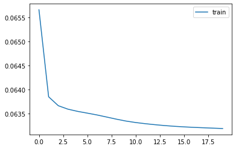

```
([0.07050558179616928, 0.6308836340904236],
 None)
```

```python
x = ['correct t-1']
y = ['correct']
run_model(x,y)
```

#### Model with time to answer

Then, we add "time to answer" to our simple model. Note that we add the variable "time to answer" at time t-1, because in real life, we do not have the time to answer of the actual question at time t before answering it.

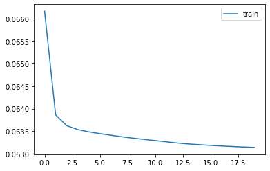

```
([0.07045544683933258, 0.63193678855896],
 None)
```

```python
x = ['correct t-1', 'time_to_answer_t_1']
y = ['correct']
run_model(x,y)
```

#### Model with domains

We add all domains to our model.

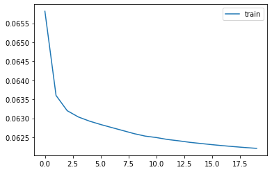

```
([0.06966584175825119, 0.6480653285980225],
 None)
```

```python
x = [i for i in df_neural_net_training.columns if i.startswith('domain') or i == 'correct t-1']
y = ['correct']
run_model(x,y)
```

#### Model with skills

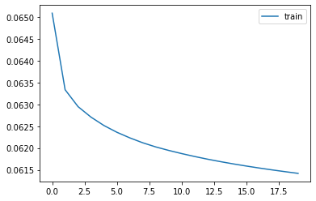

```
([0.06889030337333679, 0.6622412204742432],
 None)
```

```python
x = [i for i in df_neural_net_training.columns if i.startswith('skill') or i == 'correct t-1']
y = ['correct']
run_model(x,y)
```

#### Model with sub-skills

We add all sub-skills to our model.

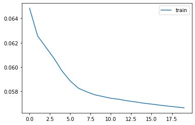

```
([0.06344286352396011, 0.742033064365387],
 None)
```

```python
x = [i for i in df_neural_net_training.columns if i.startswith('sub_skill') or i == 'correct t-1']
y = ['correct']
run_model(x,y)
```

#### Model with questions

We add all questions to our model.

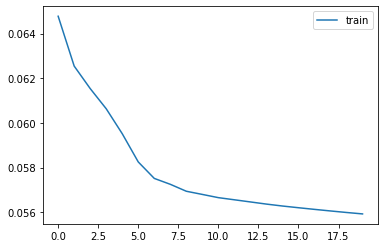

```
([0.06269364058971405, 0.7513524889945984],
 None)
```

```python
x = [i for i in df_neural_net_training.columns if i.startswith('question') or i == 'correct t-1']
y = ['correct']
run_model(x,y)
```

#### Model with number of attempts

We add the number of attempts to our model.

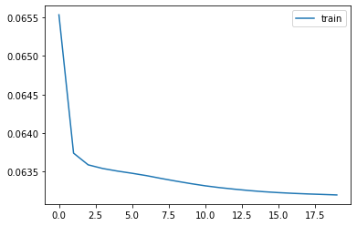

```
([0.07046093046665192, 0.6319640874862671],
 None)
```

```python
x = ['correct t-1', 'attempt']
y = ['correct']
run_model(x,y)
```

#### Metamodel

Finally, we add all variables to our model to check whether this drastically improves the AUC.

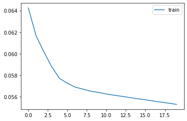

```
([0.06207801401615143, 0.7579972743988037],
 None)
```

```python
x = [i for i in df_neural_net_training.columns if i.startswith('domain') or i.startswith('sub_skill') or i.startswith('question') or i.startswith('skill')  or  i == 'correct t-1' or i == 'time_to_answer_t_1' or i == 'attempt']
y = ['correct']
run_model(x,y)
```

# Analysis of results

```python
results = pd.read_excel('gs://bucket_unilever/LSTM O/DKT.xlsx')
results.set_index('Set').round(decimals=3)
```

[output not shown]

All the models that we ran got a similar AUC for the training and testing sets. This was expected, as we voluntarily chose a low number of units in the LSTM layer, helping the model to generalize and to run faster.

2) Adding variables improves the model significantly, especially with sub-skills and questions. We can see that the AUC of the Meta DKT is very similar to the AUC of the model with sub-skills and the model with questions. This means that these 2 variables are particularly good predictors of performance. This makes sense, since these are 2 precise variables that allow the model to analyze whether a certain question or sub-skill is particularly hard. In simple terms, the model knows which questions or sub-skills are very hard, so it is capable to predict whether a new user will likely struggle. If 90% of users failed a question, it is very likely that a new user will also fail the question, so this is a very good indicator.

To conclude, I would advise platforms to use the DKT model with the questions variable. The results with this variable are significantly better than the BKT model, and the model still runs really fast, especially with a simple architecture. While my goal was not to find the best architecture for this specific dataset but rather to compare different models, I would advise platforms to test various architectures and carefully hypertune parameters of the DKT model with questions, in order to get the best predictions for their users. As a final note, one disadvantage of DKT over BKT is that it requires large amounts of training data, and so is well suited to an online educational platform, but not a small classroom environment.

# References

● Ryan S.J.d. Baker, Albert T. Corbett, Vincent Aleven : More Accurate Student Modeling Through Contextual Estimation of Slip and Guess Probabilities in Bayesian Knowledge Tracing. 2008.

● Zachary A. Pardos , Neil T. Heffernan : Modeling Individualization in a Bayesian Networks Implementation of Knowledge Tracing. 2010.

● Chris Piech , Jonathan Bassen , Jonathan Huang, Surya Ganguli , Mehran Sahami , Leonidas Guibas , Jascha Sohl-Dickstein : Deep Knowledge Tracing. 2015.

● Badrinath, A., Wang, F., Pardos, Z.A. (2021) pyBKT: An Accessible Python Library of Bayesian Knowledge Tracing Models. In S. Hsiao, & S. Sahebi (Eds.) Proceedings of the 14th International Conference on Educational Data Mining (EDM). Pages 468-474.

● Shayan Doroudi and Emma Brunskill. 2017. The Misidentified Identifiability Problem of Bayesian Knowledge Tracing.

● Shayan Doroudi and Emma Brunskill. 2019. Fairer but Not Fair Enough On the Equitability of Knowledge Tracing. In The 9th International Learning Analytics & Knowledge Conference (LAK19), March 4–8, 2019, Tempe, AZ, US